# CIND 123 - Data Analytics: Basic Methods

## Question 3 (25 points)

On average, John receives 3 emails a day.

1. Calculate all the probabilities that John receives 2, 3, …, to 9 emails in a day. (5 points)

```r
## Loading the Poisson distribution function
library(stats)

## Mean number of emails per day
lambda <- 3

## Number of emails from 2 to 9
num_emails <- 2:9

## Calculate probabilities
probabilities <- dpois(num_emails, lambda)

## Printing the probabilities
for (i in 1:length(num_emails)) {
  cat("Probability of receiving", num_emails[i], "emails in a day:", probabilities[i], "\n")
}
```

```
## Probability of receiving 2 emails in a day: 0.2240418
## Probability of receiving 3 emails in a day: 0.2240418
## Probability of receiving 4 emails in a day: 0.1680314
## Probability of receiving 5 emails in a day: 0.1008188
## Probability of receiving 6 emails in a day: 0.05040941
## Probability of receiving 7 emails in a day: 0.02160403
## Probability of receiving 8 emails in a day: 0.008101512
## Probability of receiving 9 emails in a day: 0.002700504
```

2. Determine the probability that John receives 4 emails or more in a day. (5 points)

```r
## Loading the Poisson distribution function
library(stats)

## Mean number of emails per day
lambda <- 3

## Probability of receiving 4 or more emails
prob_4_or_more <- 1 - ppois(3, lambda)

## Printing the probability
cat("Probability of receiving 4 or more emails in a day:", prob_4_or_more, "\n")
```

```
## Probability of receiving 4 or more emails in a day: 0.3527681
```

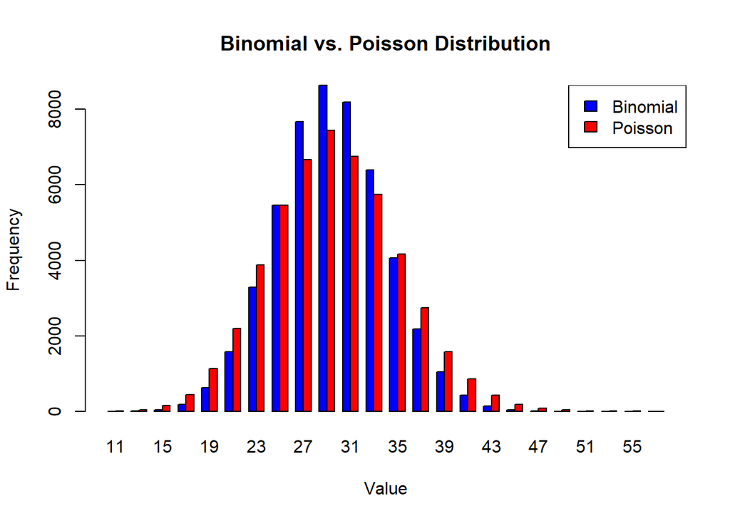

```r
## Loading the required package
install.packages("plotrix")  # Install only if not installed already
library(plotrix)

## Parameters for question
n <- 100  # Number of trials
p <- 0.3  # Probability of success
lambda <- n * p  # Poisson parameter

## Step 1: Generate 50,000 samples for a Binomial random variable
binomial_samples <- rbinom(50000, size = n, prob = p)

## Step 2: Generate 50,000 samples for a Poisson random variable
poisson_samples <- rpois(50000, lambda = lambda)

## Step 3: Illustrate the similarity using multhist()
multhist(list(binomial_samples, poisson_samples), col = c("blue", "red"),
         xlab = "Value", ylab = "Frequency", main = "Binomial vs. Poisson Distribution")

## Adding a legend
legend("topright", legend = c("Binomial", "Poisson"), fill = c("blue", "red"))
```

## Question 4 (20 points)

Write a script in R to compute the following probabilities of a normal random variable with mean 12 and variance 36.

1. Calculate the probability that it lies between 10.5 and 18.7 (inclusive). (5 points)

```r
## Parameters for question
mean <- 12
variance <- 36
lower_bound <- 10.5
upper_bound <- 18.7

## Calculating standard deviation (square root of variance)
sd <- sqrt(variance)

## Calculating the probability using the CDF of the normal distribution
probability <- pnorm(upper_bound, mean, sd) - pnorm(lower_bound, mean, sd)

## Printing the results
cat("Probability that the random variable lies between", lower_bound, "and", upper_bound, "inclusive:", probability, "\n")
```

```
## Probability that the random variable lies between 10.5 and 18.7 inclusive: 0.4666379
```

2. Determine the probability that it is greater than 16.03. (5 points)

```r
## Parameters for question
mean <- 12
variance <- 36
threshold <- 16.03

## Calculating standard deviation (square root of variance)
sd <- sqrt(variance)

## Calculating the probability using the complement of the CDF of the normal distribution
probability <- 1 - pnorm(threshold, mean, sd)

## Printing the results
cat("Probability that the random variable is greater than", threshold, ":", probability, "\n")
```

```
## Probability that the random variable is greater than 16.03 : 0.250898
```

3. Find the probability that it is less than or equal to 14.2. (5 points)

```r
## Parameters for question
mean <- 12
variance <- 36
threshold <- 14.2

## Calculating standard deviation (square root of variance)
sd <- sqrt(variance)

## Calculating the probability using the CDF of the normal distribution
probability <- pnorm(threshold, mean, sd)

## Printing the results
cat("Probability that the random variable is less than or equal to", threshold, ":", probability, "\n")
```

```
## Probability that the random variable is less than or equal to 14.2 : 0.6430662
```

4. Compute the probability that it is less than 11 or greater than 14. (5 points)

```r
## Parameters for question
mean <- 12
variance <- 36
lower_threshold <- 11
upper_threshold <- 14

## Calculating standard deviation (square root of variance)
sd <- sqrt(variance)

## Calculating probabilities using the cumulative distribution function (CDF)
probability_less_than_11 <- pnorm(lower_threshold, mean, sd)
probability_greater_than_14 <- 1 - pnorm(upper_threshold, mean, sd)

## Probability that the random variable is less than 11 or greater than 14
probability <- probability_less_than_11 + probability_greater_than_14

## Printing the results
cat("Probability that the random variable is less than 11 or greater than 14:", probability, "\n")
```

```
## Probability that the random variable is less than 11 or greater than 14: 0.8032575
```

END of Assignment #2.